# 3. Population Structure and Relatedness Inference

Population structure due to genetic ancestry and genetic correlation due to sample relatedness are important factors to consider when performing association tests as their presence can lead to mis-calibration of test statistics and false positive associations. This tutorial demonstrates how to perform population structure and relatedness inference using the [GENESIS](https://bioconductor.org/packages/release/bioc/html/GENESIS.html) and [SNPRelate](https://www.bioconductor.org/packages/release/bioc/html/SNPRelate.html) R/Bioconductor packages. We will use the results of this inference to improve our association testing in the following Mixed Models tutorial.

## LD-pruning

We generally advise that population structure and relatedness inference be performed using a set of (nearly) independent genetic variants. To find this set of variants, we perform linkage-disequilibrium (LD) pruning on the study sample set. We typically use an LD threshold of `r^2 < 0.1` to select variants. We use the SNPRelate package to perform LD-pruning with GDS files.

```r
library(SeqArray)
repo_path <- "https://github.com/UW-GAC/SISG_2022/raw/main"

# use a GDS file with all chromosomes
if (!dir.exists("data")) dir.create("data")
gdsfile <- "data/1KG_phase3_subset.gds"
if (!file.exists(gdsfile)) download.file(file.path(repo_path, gdsfile), gdsfile)
gdsfmt::showfile.gds(closeall=TRUE) # make sure file is not already open
gds <- seqOpen(gdsfile)

# run LD pruning
library(SNPRelate)
set.seed(100) # LD pruning has a random element; so make this reproducible
snpset <- snpgdsLDpruning(gds,
                          method="corr",
                          slide.max.bp=10e6,
                          ld.threshold=sqrt(0.1))
```

```
## SNV pruning based on LD:
## Excluding 1,120 SNVs on non-autosomes
## Calculating allele counts/frequencies ...
##
[..................................................]  0%, ETC: ---
[==================================================] 100%, completed, 0s
## # of selected variants: 24,387
## Excluding 253 SNVs (monomorphic: TRUE, MAF: NaN, missing rate: NaN)
##     # of samples: 1,126
##     # of SNVs: 24,387
##     using 1 thread
##     sliding window: 10,000,000 basepairs, Inf SNPs
##     |LD| threshold: 0.316228
##     method: correlation
## Chromosome 1: 92.23%, 1,033/1,120
## Chromosome 2: 91.16%, 1,021/1,120
## Chromosome 3: 91.16%, 1,021/1,120
## Chromosome 4: 91.16%, 1,021/1,120
## Chromosome 5: 91.88%, 1,029/1,120
## Chromosome 6: 89.02%, 997/1,120
## Chromosome 7: 90.54%, 1,014/1,120
## Chromosome 8: 89.02%, 997/1,120
## Chromosome 9: 88.66%, 993/1,120
## Chromosome 10: 86.88%, 973/1,120
## Chromosome 11: 86.79%, 972/1,120
## Chromosome 12: 88.30%, 989/1,120
## Chromosome 13: 86.34%, 967/1,120
## Chromosome 14: 84.46%, 946/1,120
## Chromosome 15: 84.11%, 942/1,120
## Chromosome 16: 83.93%, 940/1,120
## Chromosome 17: 84.91%, 951/1,120
## Chromosome 18: 84.46%, 946/1,120
## Chromosome 19: 81.96%, 918/1,120
## Chromosome 20: 82.05%, 919/1,120
## Chromosome 21: 75.09%, 841/1,120
## Chromosome 22: 76.52%, 857/1,120
## 21,287 markers are selected in total.
```

```r
# how many variants on each chr?
sapply(snpset, length)
```

```
##  chr1  chr2  chr3  chr4  chr5  chr6  chr7  chr8  chr9 chr10 chr11 chr12 chr13
##  1033  1021  1021  1021  1029   997  1014   997   993   973   972   989   967
## chr14 chr15 chr16 chr17 chr18 chr19 chr20 chr21 chr22
##   946   942   940   951   946   918   919   841   857
```

```r
# get the full list of LD-pruned variants
pruned <- unlist(snpset, use.names=FALSE)
length(pruned)
```

```
## [1] 21287
```

## Computing a GRM

We can use the SNPRelate package to compute a Genetic Relationship matrix (GRM) using GDS files. A GRM captures genetic correlation among samples due to both distant ancestry (i.e. population structure) and recent kinship (i.e. familial relatedness) in a single matrix.

SNPRelate offers several algorithms for computing a GRM, including the commonly-used GCTA [Yang et al 2011](https://www.ncbi.nlm.nih.gov/pubmed/21167468) (`method = "GCTA"`) and allelic matching based estimators described by [Weir and Goudet 2017](https://www.ncbi.nlm.nih.gov/pubmed/28550018) (`method = "IndivBeta"`).

```r
# compute the GRM using the GCTA method
library(SNPRelate)
grm <- snpgdsGRM(gds, method="GCTA", snp.id = pruned)
```

```
## Genetic Relationship Matrix (GRM, GCTA):
## Calculating allele counts/frequencies ...
##
[..................................................]  0%, ETC: ---
[==================================================] 100%, completed, 1s
## # of selected variants: 21,287
##     # of samples: 1,126
##     # of SNVs: 21,287
##     using 1 thread
## CPU capabilities: Double-Precision SSE2
## Thu Jul  6 22:30:38 2023    (internal increment: 436)
##
[..................................................]  0%, ETC: ---
[==================================================] 100%, completed, 3s
## Thu Jul  6 22:30:41 2023    Done.
```

```r
names(grm)
```

```
## [1] "sample.id" "snp.id"    "method"    "grm"
```

```r
dim(grm$grm)
```

```
## [1] 1126 1126
```

```r
# look at the top corner of the matrix
grm$grm[1:5,1:5]
```

```
##            [,1]       [,2]       [,3]       [,4]       [,5]
## [1,] 0.72284858 0.03428003 0.02475889 0.04051960 0.02397084
## [2,] 0.03428003 0.74335217 0.02098193 0.02772272 0.02125452
## [3,] 0.02475889 0.02098193 0.48389966 0.03247437 0.03382292
## [4,] 0.04051960 0.02772272 0.03247437 0.80364821 0.02771950
## [5,] 0.02397084 0.02125452 0.03382292 0.02771950 0.47465797
```

## De-convoluting ancestry and relatedness

To disentangle distant ancestry (i.e. population structure) from recent kinship (i.e. familial relatedness), we implement the analysis described in Conomos et al., 2016. This approach uses the [KING-robust](http://www.ncbi.nlm.nih.gov/pubmed/20926424), [PC-AiR](http://www.ncbi.nlm.nih.gov/pubmed/25810074), and [PC-Relate](http://www.ncbi.nlm.nih.gov/pubmed/26748516) methods.

#### KING-robust

Step 1 is to get initial kinship estimates using [KING-robust](http://www.ncbi.nlm.nih.gov/pubmed/20926424), which is robust to discrete population structure but not ancestry admixture. KING-robust will be able to identify close relatives (e.g. 1st and 2nd degree) reliably, but may identify spurious pairs or miss more distant pairs of relatives in the presence of admixture. KING is available as its own software, but the KING-robust algorithm is also available in SNPRelate via the function `snpgdsIBDKING`.

```r
# run KING-robust
king <- snpgdsIBDKING(gds, snp.id=pruned)
```

```
## IBD analysis (KING method of moment) on genotypes:
## Calculating allele counts/frequencies ...
##
[..................................................]  0%, ETC: ---
[==================================================] 100%, completed, 0s
## # of selected variants: 21,287
##     # of samples: 1,126
##     # of SNVs: 21,287
##     using 1 thread
## No family is specified, and all individuals are treated as singletons.
## Relationship inference in the presence of population stratification.
## CPU capabilities: Double-Precision SSE2
## Thu Jul  6 22:30:41 2023    (internal increment: 13952)
##
[..................................................]  0%, ETC: ---
[==================================================] 100%, completed, 2s
## Thu Jul  6 22:30:43 2023    Done.
```

```r
names(king)
```

```
## [1] "sample.id" "snp.id"    "afreq"     "IBS0"      "kinship"
```

```r
# extract the kinship estimates
kingMat <- king$kinship
colnames(kingMat) <- rownames(kingMat) <- king$sample.id
dim(kingMat)
```

```
## [1] 1126 1126
```

```r
# look at the top corner of the matrix
kingMat[1:5,1:5]
```

```
##             HG00096      HG00097     HG00099      HG00100     HG00101
## HG00096 0.500000000  0.013295347 0.021206409  0.003261883 0.021668220
## HG00097 0.013295347  0.500000000 0.007122507 -0.009021842 0.003561254
## HG00099 0.021206409  0.007122507 0.500000000  0.037700283 0.020028275
## HG00100 0.003261883 -0.009021842 0.037700283  0.500000000 0.016992551
## HG00101 0.021668220  0.003561254 0.020028275  0.016992551 0.500000000
```

We extract pairwise kinship estimates and IBS0 values (the proportion of variants for which the pair of indivdiuals share 0 alleles identical by state) to plot. We use a hexbin plot to visualize the relatedness for all pairs of samples.

```r
kinship <- snpgdsIBDSelection(king)
head(kinship)
```

```
##       ID1     ID2        IBS0      kinship
## 1 HG00096 HG00097 0.007986095  0.013295347
## 2 HG00096 HG00099 0.007845164  0.021206409
## 3 HG00096 HG00100 0.008831681  0.003261883
## 4 HG00096 HG00101 0.007939118  0.021668220
## 5 HG00096 HG00102 0.008737727 -0.003362152
## 6 HG00096 HG00103 0.007939118  0.026241799
```

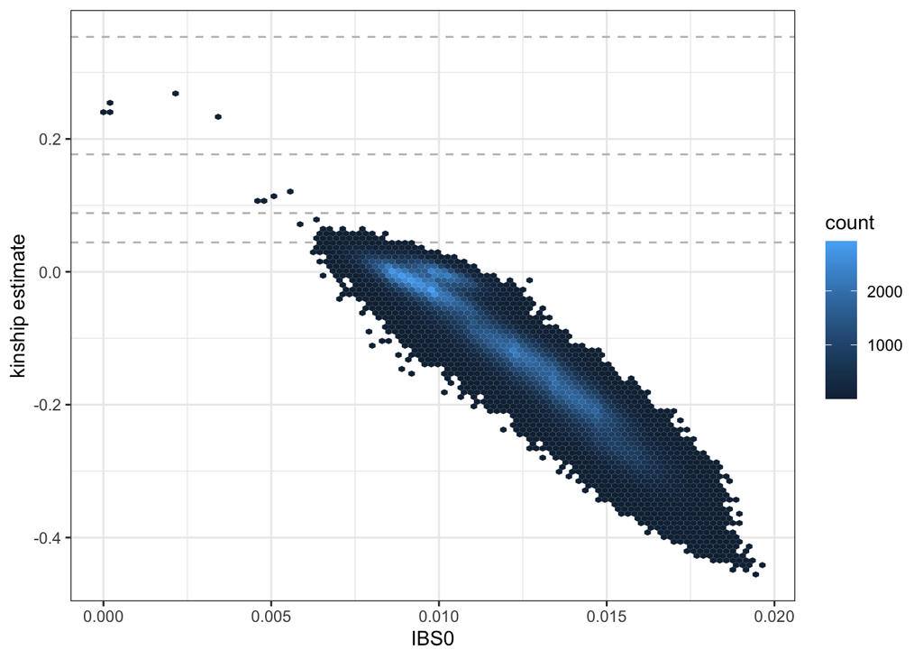

```r
library(ggplot2)
ggplot(kinship, aes(IBS0, kinship)) +
    geom_hline(yintercept=2^(-seq(3,9,2)/2), linetype="dashed", color="grey") +
    geom_hex(bins = 100) +
    ylab("kinship estimate") +
    theme_bw()
```

We see a few parent-offspring, full sibling, 2nd degree, and 3rd degree relative pairs. The abundance of negative estimates represent pairs of individuals who have ancestry from different populations – the magnitude of the negative relationship is informative of how different their ancestries are; more on this below.

#### PC-AiR

The next step is [PC-AiR](http://www.ncbi.nlm.nih.gov/pubmed/25810074), which provides robust population structure inference in samples with kinship and pedigree structure. PC-AiR is available in the GENESIS package via the function `pcair`.

First, PC-AiR partitions the full sample set into a set of mutually unrelated samples that is maximally informative about all ancestries in the sample (i.e. the unrelated set) and their relatives (i.e. the related set). We use a 3rd degree kinship threshold (`kin.thresh = 2^(-9/2)`), which corresponds to first cousins – this defines anyone less related than first cousins as “unrelated”. We use the negative KING-robust estimates as “ancestry divergence” measures (`divMat`) to identify pairs of samples with different ancestry – we preferentially select individuals with many negative estimates for the unrelated set to ensure ancestry representation. For now, we also use the KING-robust estimates as our kinship measures (`kinMat`); more on this below.

Once the unrelated and related sets are identified, PC-AiR performs a standard Principal Component Analysis (PCA) on the unrelated set of individuals and then projects the relatives onto the PCs. Under the hood, PC-AiR uses the SNPRelate package for efficient PC computation and projection.

```r
# run PC-AiR
library(GENESIS)
pca <- pcair(gds,
            kinobj = kingMat,
            kin.thresh = 2^(-9/2),
            divobj = kingMat,
            div.thresh = -2^(-9/2),
            snp.include = pruned)
```

```
## Using kinobj and divobj to partition samples into unrelated and related sets
```

```
## Working with 1126 samples
```

```
## Identifying relatives for each sample using kinship threshold 0.0441941738241592
```

```
## Identifying pairs of divergent samples using divergence threshold -0.0441941738241592
```

```
## Partitioning samples into unrelated and related sets...
```

```
## Unrelated Set: 1040 Samples
## Related Set: 86 Samples
```

```
## Performing PCA on the Unrelated Set...
```

```
## Principal Component Analysis (PCA) on genotypes:
## Calculating allele counts/frequencies ...
##
[..................................................]  0%, ETC: ---
[==================================================] 100%, completed, 0s
## # of selected variants: 20,745
## Excluding 542 SNVs (monomorphic: TRUE, MAF: NaN, missing rate: NaN)
##     # of samples: 1,040
##     # of SNVs: 20,745
##     using 1 thread
##     # of principal components: 32
## CPU capabilities: Double-Precision SSE2
## Thu Jul  6 22:30:47 2023    (internal increment: 472)
##
[..................................................]  0%, ETC: ---
[==================================================] 100%, completed, 3s
## Thu Jul  6 22:30:50 2023    Begin (eigenvalues and eigenvectors)
## Thu Jul  6 22:30:50 2023    Done.
```

```
## Predicting PC Values for the Related Set...
```

```
## SNP Loading:
##     # of samples: 1,040
##     # of SNPs: 20,745
##     using 1 thread
##     using the top 32 eigenvectors
## Thu Jul  6 22:30:50 2023    (internal increment: 3780)
##
[..................................................]  0%, ETC: ---
[==================================================] 100%, completed, 1s
## Thu Jul  6 22:30:51 2023    Done.
## Sample Loading:
##     # of samples: 86
##     # of SNPs: 20,745
##     using 1 thread
##     using the top 32 eigenvectors
## Thu Jul  6 22:30:51 2023    (internal increment: 45720)
##
[..................................................]  0%, ETC: ---
[==================================================] 100%, completed, 0s
## Thu Jul  6 22:30:51 2023    Done.
```

```r
names(pca)
```

```
##  [1] "vectors"    "values"     "rels"       "unrels"     "kin.thresh"
##  [6] "div.thresh" "sample.id"  "nsamp"      "nsnps"      "varprop"
## [11] "call"       "method"
```

```r
# the unrelated set of samples
length(pca$unrels)
```

```
## [1] 1040
```

```r
head(pca$unrels)
```

```
## [1] "HG00096" "HG00097" "HG00099" "HG00100" "HG00101" "HG00102"
```

```r
# the related set of samples
length(pca$rels)
```

```
## [1] 86
```

```r
head(pca$rels)
```

```
## [1] "NA18553" "NA19010" "HG00240" "HG01958" "NA18974" "NA19720"
```

```r
# extract the top 10 PCs and make a data.frame
pcs <- data.frame(pca$vectors[,1:10])
colnames(pcs) <- paste0('PC', 1:10)
pcs$sample.id <- pca$sample.id
dim(pcs)
```

```
## [1] 1126   11
```

```r
head(pcs)
```

```
##                 PC1         PC2          PC3          PC4         PC5
## HG00096 -0.02226595 -0.03721118 -0.009162030 -0.005479143 -0.03943083
## HG00097 -0.02035821 -0.03354150 -0.008732338 -0.005212741 -0.03440744
## HG00099 -0.02124471 -0.03392772 -0.011968941 -0.004212789 -0.03292659
## HG00100 -0.02064631 -0.04075052 -0.014844603 -0.003601802 -0.04319511
## HG00101 -0.02072169 -0.03528002 -0.009883181 -0.001348310 -0.03345653
## HG00102 -0.02187220 -0.04050299 -0.011270547  0.001939760 -0.02917086
##                   PC6           PC7          PC8           PC9          PC10
## HG00096 -0.0023634637 -0.0002352025  0.001462893 -0.0038031231  0.0016164603
## HG00097 -0.0014944132  0.0016601806  0.001439643 -0.0030539183 -0.0010562435
## HG00099 -0.0002413407  0.0003622018  0.001411739 -0.0007166033 -0.0006072856
## HG00100 -0.0017489028 -0.0010607122 -0.001589142 -0.0004970386  0.0011166639
## HG00101  0.0003224451 -0.0035162044 -0.001026124 -0.0039774511 -0.0011347434
## HG00102 -0.0020650751 -0.0002454989 -0.002454935 -0.0024755851  0.0015934108
##         sample.id
## HG00096   HG00096
## HG00097   HG00097
## HG00099   HG00099
## HG00100   HG00100
## HG00101   HG00101
## HG00102   HG00102
```

```r
# save output
save(pcs, file="data/pcs.RData")
```

We’d like to determine which PCs are ancestry informative. To do this we look at the PCs in conjunction with reported population information for the 1000 Genomes samples. This information is stored in the `AnnotatedDataFrame` we created in the prior tutorial. We make a parallel coordinates plot, color-coding by 1000 Genomes population.

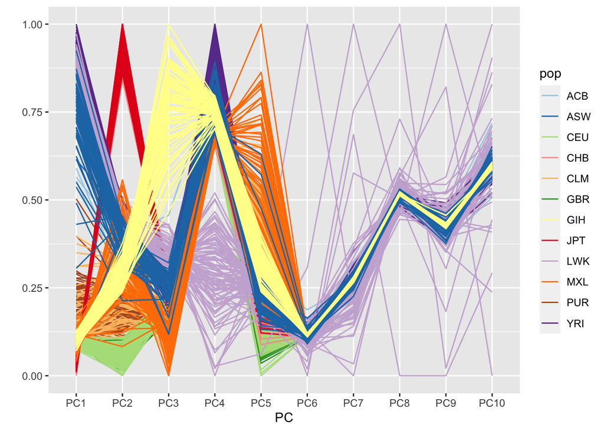

```r
library(Biobase)
annotfile <- "data/sample_phenotype_annotation.RData"
if (!file.exists(annotfile)) download.file(file.path(repo_path, annotfile), annotfile)
annot <- get(load(annotfile))

pc.df <- merge(pcs, pData(annot)[,c("sample.id", "pop")], by = "sample.id")

library(GGally)
library(RColorBrewer)
pop.cols <- setNames(brewer.pal(12, "Paired"),
                 c("ACB", "ASW", "CEU", "GBR", "CHB", "JPT", "CLM", "MXL", "LWK", "YRI", "GIH", "PUR"))
ggparcoord(pc.df, columns=2:11, groupColumn="pop", scale="uniminmax") +
    scale_color_manual(values=pop.cols) +
    xlab("PC") + ylab("")
```

#### PC-Relate

The next step is [PC-Relate](http://www.ncbi.nlm.nih.gov/pubmed/26748516), which provides accurate kinship inference, even in the presence of population structure and ancestry admixture, by conditioning on ancestry informative PCs. As we saw above, PCs 1-5 separate populations in our study, so we condition on PCs 1-5 in our PC-Relate analysis. PC-Relate can be performed using the `pcrelate` function in GENESIS, which expects a `SeqVarIterator` object for the genotype data. The `training.set` argument allows for specification of which samples to use to “learn” the ancestry adjustment – we recommend the unrelated set from the PC-AiR analysis.

(NOTE: this will take a few minutes to run).

```r
seqResetFilter(gds, verbose=FALSE)
library(SeqVarTools)
seqData <- SeqVarData(gds)

# filter the GDS object to our LD-pruned variants
seqSetFilter(seqData, variant.id=pruned)
```

```
## # of selected variants: 21,287
```

```r
iterator <- SeqVarBlockIterator(seqData, verbose=FALSE)

pcrel <- pcrelate(iterator,
                  pcs=pca$vectors[,c(1:5)],
                  training.set=pca$unrels)
```

```
## Using 6 CPU cores
```

```
## 1126 samples to be included in the analysis...
```

```
## Betas for 5 PC(s) will be calculated using 1040 samples in training.set...
```

```
## Running PC-Relate analysis for 1126 samples using 21287 SNPs in 3 blocks...
```

```
## Performing Small Sample Correction...
```

```r
names(pcrel)
```

```
## [1] "kinBtwn" "kinSelf"
```

```r
# relatedness between pairs of individuals
dim(pcrel$kinBtwn)
```

```
## [1] 633375      6
```

```r
head(pcrel$kinBtwn)
```

```
##       ID1     ID2           kin        k0          k2 nsnp
## 1 HG00096 HG00097  0.0134027785 0.9137695 -0.03261940 4191
## 2 HG00096 HG00099  0.0007317264 0.9601136 -0.03695950 4191
## 3 HG00096 HG00100 -0.0028495849 0.9882875 -0.02311084 4174
## 4 HG00096 HG00101  0.0036727320 0.9615588 -0.02375027 4191
## 5 HG00096 HG00102  0.0105132687 0.9770769  0.01912996 4165
## 6 HG00096 HG00103  0.0109929824 0.9354029 -0.02062514 4204
```

```r
# self-kinship estimates
dim(pcrel$kinSelf)
```

```
## [1] 1126    3
```

```r
head(pcrel$kinSelf)
```

```
##        ID            f nsnp
## 1 HG00096 -0.012471522 4222
## 2 HG00097 -0.005100475 4301
## 3 HG00099 -0.067116111 4272
## 4 HG00100  0.012603466 4240
## 5 HG00101 -0.039850636 4271
## 6 HG00102  0.033038667 4226
```

```r
# save output
save(pcrel, file="data/pcrelate.RData")
```

We plot the pairwise kinship estimates againts the IBD0 (`k0`) estimates (the proportion of variants for which the pair of individuals share 0 alleles identical by descent). We use a hexbin plot to visualize the relatedness for all pairs of samples.

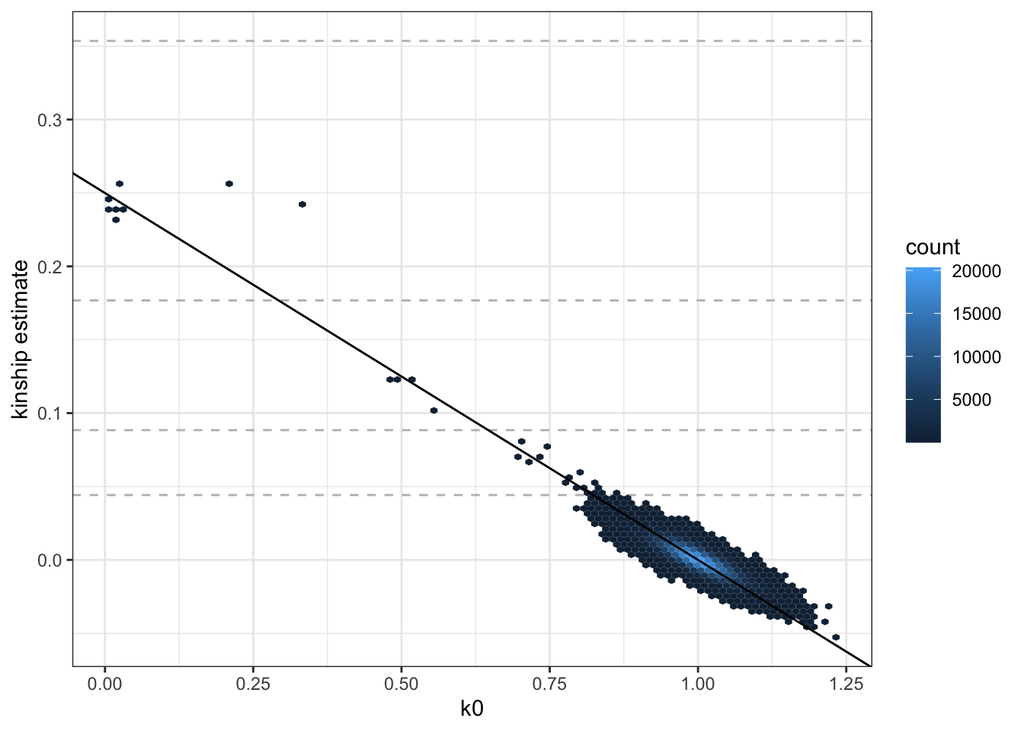

```r
ggplot(pcrel$kinBtwn, aes(k0, kin)) +
    geom_hline(yintercept=2^(-seq(3,9,2)/2), linetype="dashed", color="grey") +
    geom_hex(bins = 100) +
    geom_abline(intercept = 0.25, slope = -0.25) +
    ylab("kinship estimate") +
    theme_bw()
```

We see that the PC-Relate relatedness estimates for unrelated pairs (i.e. kin ~ 0 and k0 ~ 1) are much closer to expectation than those from KING-robust.

### Advanced Notes

In small samples (such as this one), we recommend performing a second iteration of PC-AiR and PC-Relate. Using the first iteration of PC-Relate ancestry-adjusted kinship estimates, we can often better partition our sample into unrelated and related sets, which leads to better ancestry PCs from PC-AiR and better relatedness estimates from PC-Relate. The steps to perform the second iteration are:

1. Perform a second PC-AiR analysis using the PC-Relate kinship matrix as the kinship estimates. Still use the (original) KING-robust matrix for the ancestry divergence estimates.
2. Perform a second PC-Relate analysis using the new PC-AiR PCs to adjust for population structure.

In large samples (such as TOPMed), the KING-robust and PC-Relate analyses can be very time consuming, so we suggest the following alternative procedure for deconvoluting ancestry and relatedness:

1. Use the [KING-IBDseg method](https://www.kingrelatedness.com/manual.shtml#IBDSEG) to estimate kinship for all pairs of individuals. This method uses a fast algorithm to approximate IBD segments based on identity by state and works well in the presence of ancestry admixture – in our experience, it gives very similar results to PC-Relate. The software to run KING-IBDseg uses PLINK files, but we’ve written a `KING IBDseg` application on the BioData Catalyst powered by Seven Bridges platform that will use GDS files as input (it does a conversion from GDS to PLINK).
2. Perform a PC-AiR analysis to infer population structure using the KING-IBDseg estimates as the kinship estimates and using no ancestry divergence measures (in large samples, the PC-AiR algorithm works well even without the ancestry divergence).

### Exercise 3.1 (Application)

Use the `LD Pruning` app on the BioData Catalyst powered by Seven Bridges platform to perform LD pruning on the example 1000 Genomes GDS files you created previously. The steps to perform this analysis are as follows:

- Copy the app to your project if it is not already there:
  - Click: Public Gallery > Apps > Browse
  - Search for `LD Pruning`
  - Click: Copy > Select your project > Copy
- Run the analysis in your project:
  - Click: Apps > `LD Pruning` > Run
  - Specify the Inputs:
    - GDS Files: `1KG_phase3_subset_chr<CHR>.gds` (select all 22 chromosomes)
  - Specify the App Settings:
    - Autosomes only: TRUE
    - LD |r| threshold: 0.32 ($\approx r^2 = 0.1$)
    - MAF threshold: 0 (in practice we usually use 0.01 or 0.05, but our example data doesn’t have many variants)
    - Output prefix: “1KG_phase3_subset” (or any other string to name the output file)
  - Click: Run

The analysis will take a few minutes to run. You can find your analysis in the Tasks menu of your Project. Use the “View stats & logs” button to check on the status of your tasks. Click on the bar that says “ld_pruning”, click “View Logs”, and click one of the “ld_pruning” folders (there’s one per chromosome). In here you can see detailed logs of the job; take a look at the `job.out.log` and `job.err.log` – these can be useful for debugging issues.

The output of this analysis will be a single file (`<output prefix>_pruned.gds`) with the genotype data from the LD pruned variants across all 22 chromosomes.

You can find the expected output of this analysis by looking at the existing task `02. 1KG LD Pruning` in the Tasks menu of your Project. The output files are available in the Project, so you do not need to wait for your analysis to finish to move to the next exercise.

### Exercise 3.2 (Application)

Use the `KING robust` app on the BioData Catalyst powered by Seven Bridges platform to perform a KING-robust analysis of the example 1000 Genomes data using the LD pruned variants. The steps to perform this analysis are as follows:

- Copy the app to your project if it is not already there:
  - Click: Public Gallery > Apps > Browse
  - Search for `KING robust`
  - Click: Copy > Select your project > Copy
- Run the analysis in your project:
  - Click: Apps > `KING robust` > Run
  - Specify the Inputs:
    - GDS file: `1KG_phase3_subset_pruned.gds` (has pruned variants from all 22 chromosomes)
  - Specify the App Settings:
    - kinship_plots > Kinship plotting threshold: 0
    - Output prefix: “1KG_phase3_subset” (or any other string to name the output file)
  - Click: Run

The analysis will take a few minutes to run. You can find your analysis in the Tasks menu of your Project to check on its progress and see the results once it has completed.

The output of this analysis will be a `<output_prefix>_king_robust.gds` file that has the kinship estimates and a `<output_prefix>_king_robust_all.pdf` with the plot of estimated kinship vs. IBS0. Look at the kinship plot – how many 1st degree relative pairs are identified? How many 2nd degree relative pairs are identified?

You can find the expected output of this analysis by looking at the existing task `03. 1KG King Robust` in the Tasks menu of your Project. The output files are available in the Project, so you do not need to wait for your analysis to finish to move to the next exercise.

### Solution 3.2 (Application)

From the kinship plot, we can see that there are 8 1st degree relative pairs (6 parent-offspring; 2 full sibling) and 4 2nd degree relative pairs identified.

### Exercise 3.3 (Application)

Use the `PC-AiR` app on the BioData Catalyst powered by Seven Bridges platform to perform a PC-AiR analysis of the example 1000 Genomes data using the LD pruned variants. Use the KING-robust kinship estimates as both the kinship and divergence measures. The steps to perform this analysis are as follows:

- Copy the app to your project if it is not already there:
  - Click: Public Gallery > Apps > Browse
  - Search for `PC-AiR`
  - Click: Copy > Select your project > Copy
- Run the analysis in your project:
  - Click: Apps > `PC-AiR` > Run
  - Specify the Inputs:
    - Pruned GDS File: `1KG_phase3_subset_pruned.gds` (has pruned variants from all 22 chromosomes)
    - Kinship File: `1KG_phase3_subset_king_robust.gds`
    - Divergence File: `1KG_phase3_subset_king_robust.gds`
    - Phenotype file: `sample_phenotype_annotation.RData`
  - Specify the App Settings:
    - pca_byrel > Number of PCs: 10
    - pca_plots > Group: pop (sample variable for coloring output PCA)
    - pca_plots > Number of PCs: 10
    - PC-variant correlation > Run PC-variant correlation: FALSE (extra diagnostic step that takes a while to run)
    - Output prefix: “1KG_phase3_subset” (or any other string to name the output file)
  - Click: Run

The analysis will take a few minutes to run. You can find your analysis in the Tasks menu of your Project to check on its progress and see the results once it has completed.

The output of this analysis is a “_pca.RData” object with the PC values and several PC plots. Look at the parallel coordinates plot (“`<output_prefix>_parcoord.pdf`”) generated by the task. How many PCs appear to reflect population structure in the sample? This will determine how many PCs you should use to adjust PC-Relate in the next exercise.

You can find the expected output of this analysis by looking at the existing task `04. 1KG PC-AiR` in the Tasks menu of your Project. The output files are available in the Project, so you do not need to wait for your analysis to finish to move to the next exercise.

### Exercise 3.4 (Application)

Use the `PC-Relate` app on the BioData Catalyst powered by Seven Bridges platform to perform a PC-Relate analysis of the example 1000 Genomes data using the LD pruned variants. Use the PC-AiR PCs to adjust for population structure. The steps to perform this analysis are as follows:

- Copy the app to your project if it is not already there:
  - Click: Public Gallery > Apps > Browse
  - Search for `PC-Relate`
  - Click: Copy > Select your project > Copy
- Run the analysis in your project:
  - Click: Apps > `PC-Relate` > Run
  - Specify the Inputs:
    - GDS File: `1KG_phase3_subset_pruned.gds` (has pruned variants from all 22 chromosomes)
    - PCA file: `1KG_phase3_subset_pca.RData`
  - Specify the App Settings:
    - pcrelate_beta > Number of PCs: 6
    - pcrelate > Number of PCs: 6
    - pcrelate > Return IBD probabilities?: TRUE
    - kinship_plots > Kinship plotting threshold: 0
    - kinship_plots > Return IBD probabilities?: TRUE
    - Output prefix: “1KG_phase3_subset” (or any other string to name the output file)
  - Click: Run

The analysis will take a few minutes to run. You can find your analysis in the Tasks menu of your Project to check on its progress and see the results once it has completed.

The output of this analysis is a `<output_prefix>_pcrelate.RData` file that contains the PC-Relate relatedness estimates, a `<output_prefix>_pcrelate_Matrix.RData` file that contains a sparse matrix of kinship estimates (more on this in the Mixed Model tutorial), and a `<output_prefix>_pcrelate_all.pdf` with the plot of estimated kinship vs. k0. Look at the kinship plot – how many 1st degree relative pairs are identified? How many 2nd degree relative pairs are identified?

You can find the expected output of this analysis by looking at the existing task `05. 1KG PC-Relate` in the Tasks menu of your Project.

### Solution 3.4 (Application)

From the kinship plot, you can see that there are 8 1st degree relative pairs (6 parent-offspring; 2 full sibling) and 4 2nd degree relative pairs identified.